# Part I - (Loan Data Exploration)

# Multivariate Exploration

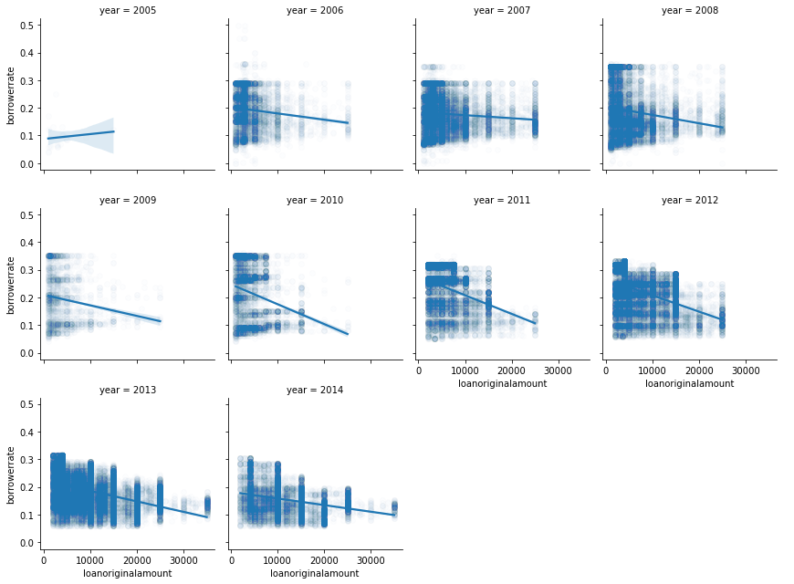

```python
plt.figure(figsize = [10, 8]);
g = sb.FacetGrid(data = loan, col = 'year', col_wrap = 4);
g.map(sb.regplot, 'loanoriginalamount', 'borrowerrate', scatter_kws={'alpha':0.01});
g.add_legend();
```

Aside from year 2005 which is an outlier because it has just 22 entries, Borrower rate seems to have a negative correlation with original loan amount across all other years. Another observation here is that there is a gradual increase in the loan amounts across the years

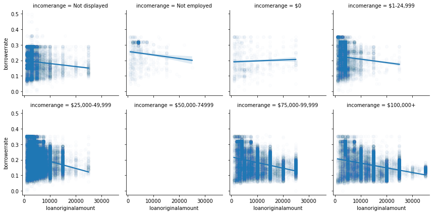

```python
plt.figure(figsize = [10, 8]);
g = sb.FacetGrid(data = loan, col = 'incomerange', col_wrap = 4);
g.map(sb.regplot, 'loanoriginalamount', 'borrowerrate', x_jitter=0.04, scatter_kws={'alpha':0.01});
g.add_legend();
```

There is a gradual increase in the loam amount as the income range increases. People with higher income ranges borrow more and people with lower incomes borrow less. The borrower rate also seems to reduce very slightly as income range increases

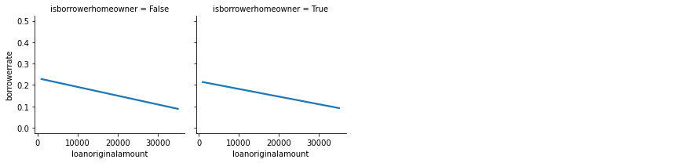

```python
plt.figure(figsize = [15, 10]);
g = sb.FacetGrid(data = loan, col = 'isborrowerhomeowner', col_wrap = 4);
g.map(sb.regplot, 'loanoriginalamount', 'borrowerrate', scatter_kws={'alpha':0.001});
g.add_legend();
```

There does not seem to be any significant positive relationship here. Both homeowners and non home owners experience lower interest rate as they borrow more money

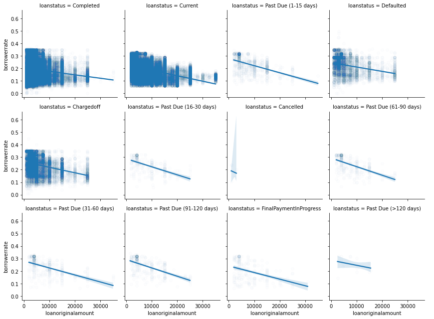

```python
plt.figure(figsize = [10, 8]);
g = sb.FacetGrid(data = loan, col = 'loanstatus', col_wrap = 4);
g.map(sb.regplot, 'loanoriginalamount', 'borrowerrate', x_jitter=0.04, scatter_kws={'alpha':0.01});
g.add_legend();
```

There seems to be a negative relationship across board here. A large category of defaulters seem to have taken smaller loans. I wonder why they are unable to pay their loans, despite their loan amounts being less than the borrowers who completed their loan payments. It could also mesn that the defaulters earn less and may not have very stable employment status

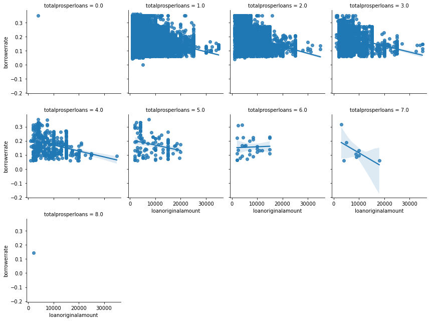

```python
plt.figure(figsize = [10, 8]);
g = sb.FacetGrid(data = loan, col = 'totalprosperloans', col_wrap = 4);
g.map(sb.regplot, 'loanoriginalamount', 'borrowerrate', x_jitter=0.0001);
g.add_legend();
```

Individuals with more number of loans seem to have borrowed less than others with fewer number of loans. Interest rate seems to be similar across plots

- The multivariate exploration showed that There is a gradual increase in the loam amount as the income range increases. People with higher income ranges borrow more and people with lower incomes borrow less. The borrower rate also seems to reduce very slightly as income range increases
- Borrower rate seems to have a negative correlation with original loan amount across all other years. Another observation here is that there is a gradual increase in the loan amounts across the years
- Individuals with more number of loans seem to have borrowed less than others with fewer number of loans.